# US Storm Analysis

## Synopsis

Storm Data is an official publication of the National Oceanic and Atmospheric Administration (NOAA), which documents several types of severe weather events that result in fatalities and or property damage. In this, we try to summarize the data based on the number of fatalities or property damage for each event type and try to figure out the worst weather events in terms of fatalities or property damage wise.

## Loading libraries

```r
#library(cacher)
library(dplyr)
```

```r
library(ggplot2)
```

## Reading data

Data Processing We read the data in R and it is ready to be processed. No clean up activity is performed on the data.

```r
data <- read.csv("C:/Users/SamJacobJulian/Downloads/repdata%2Fdata%2FStormData.csv.bz2")
head(data[,1:5])
```

```
##   STATE__           BGN_DATE BGN_TIME TIME_ZONE COUNTY
## 1       1  4/18/1950 0:00:00     0130       CST     97
## 2       1  4/18/1950 0:00:00     0145       CST      3
## 3       1  2/20/1951 0:00:00     1600       CST     57
## 4       1   6/8/1951 0:00:00     0900       CST     89
## 5       1 11/15/1951 0:00:00     1500       CST     43
## 6       1 11/15/1951 0:00:00     2000       CST     77
```

## Description

There are several type of severe weather events that result in fatalities and or property damage. In this block of code, we try to summarize the data based on the number of fatalities for each event type. Since there are so many events that don’t have any fatalities, they have been removed and the top 10 most fatal events have been listed in descending order.

```r
data_evtype <- data %>% group_by(EVTYPE) %>% summarise(sum(FATALITIES))
length(unique(data$EVTYPE))
```

```
## [1] 985
```

```r
# Separating events with fatalities
fat_ind <- which(data_evtype$`sum(FATALITIES)`>0)
fat <- data_evtype[fat_ind,]
# Top 10 disastrous events in US history
fat_ord <- fat %>% arrange(desc((fat$`sum(FATALITIES)`)))
head(fat_ord,10)
```

```
## # A tibble: 10 x 2
##            EVTYPE `sum(FATALITIES)`
##            <fctr>             <dbl>
##  1        TORNADO              5633
##  2 EXCESSIVE HEAT              1903
##  3    FLASH FLOOD               978
##  4           HEAT               937
##  5      LIGHTNING               816
##  6      TSTM WIND               504
##  7          FLOOD               470
##  8    RIP CURRENT               368
##  9      HIGH WIND               248
## 10      AVALANCHE               224
```

## Description

There are several type of severe weather events that result in fatalities and or property damage. In this block of code, we try to summarize the data based on the extent of property damage for each event type. Since there are so many events that don’t have any property damage, they have been removed and the top 10 most damaging events have been listed in descending order.

```r
data_damage <- data %>% group_by(EVTYPE) %>% summarise(sum(PROPDMG))
# Separating events with fatalities
dam_ind <- which(data_damage$`sum(PROPDMG)`>0)
dam <- data_damage[dam_ind,]
# Top 10 disastrous events in US history
dam_ord <- dam %>% arrange(desc((dam$`sum(PROPDMG)`)))
head(dam_ord,10)
```

```
## # A tibble: 10 x 2
##                EVTYPE `sum(PROPDMG)`
##                <fctr>          <dbl>
##  1            TORNADO      3212258.2
##  2        FLASH FLOOD      1420124.6
##  3          TSTM WIND      1335965.6
##  4              FLOOD       899938.5
##  5  THUNDERSTORM WIND       876844.2
##  6               HAIL       688693.4
##  7          LIGHTNING       603351.8
##  8 THUNDERSTORM WINDS       446293.2
##  9          HIGH WIND       324731.6
## 10       WINTER STORM       132720.6
```

## Results

The results clearly show us that tornadoes are the most severe weather type in US.

```r
# Finding maximum fatalities
which.max(data_evtype$`sum(FATALITIES)`)
```

```
## [1] 834
```

```r
print(data_evtype[834,])
```

```
## # A tibble: 1 x 2
##    EVTYPE `sum(FATALITIES)`
##    <fctr>             <dbl>
## 1 TORNADO              5633
```

```r
# Finding maximum damages
which.max(data_damage$`sum(PROPDMG)`)
```

```
## [1] 834
```

```r
print(data_damage[834,])
```

```
## # A tibble: 1 x 2
##    EVTYPE `sum(PROPDMG)`
##    <fctr>          <dbl>
## 1 TORNADO        3212258
```

## Plots

The plots show that tornadoes have been the most severe weather type for both human fatalities and property damage.

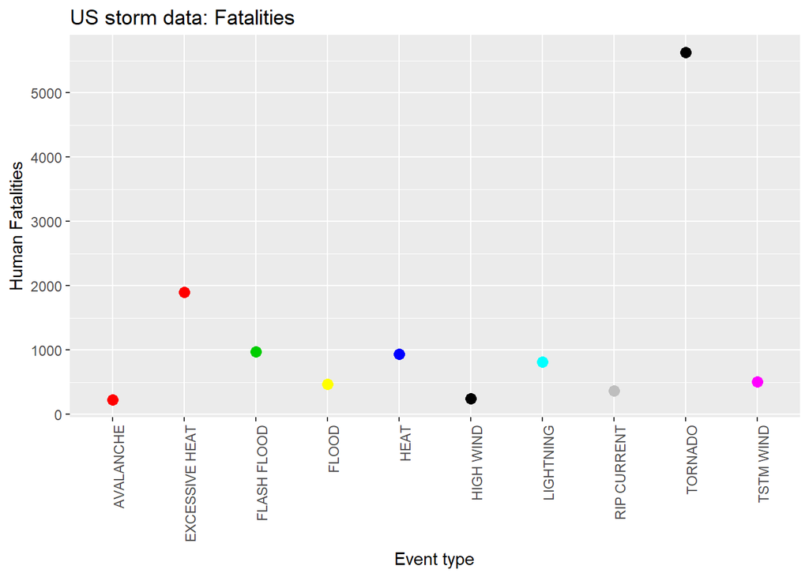

```r
sub1 <- head(fat_ord,10)
g1 <- ggplot(sub1,aes(sub1$EVTYPE,sub1$`sum(FATALITIES)`))+geom_point(col=1:10,size=3)
g1 <- g1 + ggtitle("US storm data: Fatalities") + xlab("Event type") + ylab("Human Fatalities")
g1 <- g1 + theme(axis.text.x = element_text(angle=90,hjust=1))
g1
```

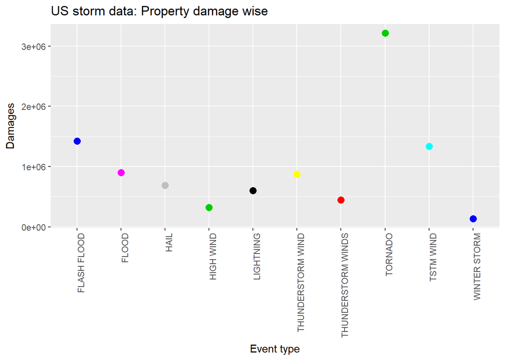

```r
sub2 <- head(dam_ord,10)
g2 <- ggplot(sub2,aes(sub2$EVTYPE,sub2$`sum(PROPDMG)`))+geom_point(col=11:20,size=3)
g2 <- g2 + ggtitle("US storm data: Property damage wise") + xlab("Event type") + ylab("Damages")
g2 <- g2 + theme(axis.text.x = element_text(angle=90,hjust=1))
g2
```